# Bioestadística Fundamental

Departamento de Estadística, Sede Bogotá

## Contenido

### Parte I: Máximo ascenso

- Motivación: optimización de procesos agrícolas.
- Idea general de la Metodología de Superficie de Respuesta.
- Diseño factorial 2^k con puntos centrales.
- Método de máximo ascenso (steepest ascent).
- Ejemplo: tomate de invernadero en Boyacá.

### Parte II: Superficies de segundo orden

- Punto estacionario del modelo cuadrático.
- Caracterización: valores y vectores propios.
- Sistemas de cresta (ridge systems).
- Optimización de respuestas múltiples y deseabilidad.

### Parte III: Diseños experimentales

- Diseños para el modelo de primer orden.
- Diseño central compuesto (CCD).
- Ejemplo: CCD para nitrógeno y fósforo.
- Bloqueo en diseños de superficie de respuesta.
- Diseños óptimos generados por computador.

### Parte IV: Otros enfoques

- Experimentos con mezclas.
- Operación evolutiva (EVOP).
- Diseño robusto de procesos.
- Taller en clase.

Metodología de Superficie de Respuesta

¿Cómo encontrar, de manera sistemática y eficiente, las condiciones de operación que maximizan el rendimiento de un proceso agrícola?

## Motivación: de la comparación a la optimización

En las clases anteriores se aprendió a **detectar** si un factor (fertilizante, densidad de siembra, riego) tiene efecto sobre una variable de respuesta. Sin embargo, en la práctica agrícola la pregunta más valiosa suele ser otra.

Pregunta de detección

¿La dosis de nitrógeno afecta el rendimiento del cultivo? (ANOVA, regresión)

Pregunta de optimización

¿Cuál es la combinación exacta de nitrógeno y fósforo que **maximiza** el rendimiento?

La **Metodología de Superficie de Respuesta** (RSM, por sus siglas en inglés) es el conjunto de técnicas estadísticas y de optimización diseñadas para responder esta segunda pregunta.

## Idea general de la RSM

La RSM modela la relación entre una variable de respuesta $y$ (rendimiento, calidad) y varios factores cuantitativos $x_1, x_2, \ldots, x_k$ (dosis de insumos), y busca de forma **secuencial** la región donde $y$ se optimiza.

**Etapa 1**  
Lejos del óptimo: modelo de primer orden y máximo ascenso.

**Etapa 2**  
Cerca del óptimo: modelo de segundo orden (curvatura).

**Etapa 3**  
Caracterización del óptimo y validación.

Esta secuencia evita experimentar exhaustivamente en todo el espacio de factores: se avanza progresivamente hacia la región de interés.

## El método de máximo ascenso

Cuando el proceso actual está **lejos** de las condiciones óptimas, la superficie de respuesta puede aproximarse razonablemente bien mediante un plano (modelo de primer orden).

Modelo de primer orden

$$\hat y = b_0 + b_1 x_1 + b_2 x_2 + \cdots + b_k x_k$$

- Se ajusta con un diseño factorial $2^k$ (o fraccionado), aumentado con puntos centrales para estimar el error puro y detectar curvatura.
- Los coeficientes $b_i$ indican cuánto cambia $\hat y$ por unidad de cambio en $x_i$ (en variables codificadas).
- El **gradiente** $(b_1, b_2, \ldots, b_k)$ define la dirección en la que $\hat y$ crece más rápidamente.

## Dirección de máximo ascenso

El método de **máximo ascenso** consiste en moverse, a partir del centro del diseño, en la dirección del gradiente del modelo de primer orden, es decir, proporcional a los coeficientes $b_1, b_2, \ldots, b_k$.

Construcción del camino de ascenso

Se fija un paso de referencia $\Delta x_1$ en la variable con mayor $|b_i|$; los demás pasos se escalan proporcionalmente:
$$\Delta x_j = \Delta x_1 \cdot \frac{b_j}{b_1}, \qquad j=2,\ldots,k$$

Se evalúa la respuesta real en puntos sucesivos sobre esta trayectoria, hasta que la respuesta deja de mejorar: ahí se ha llegado a la vecindad del óptimo.

Ejemplo central: tomate de invernadero en Boyacá

Un agrónomo busca las dosis de nitrógeno (N) y fósforo (P) que maximizan el rendimiento de tomate bajo invernadero.

## Planteamiento del problema

En un invernadero de tomate en Sutamarchán (Boyacá), la operación actual usa $N=10$ g/planta y $P=6$ g/planta, con un rendimiento promedio cercano a $38.7$ kg/planta. El agrónomo sospecha que estas dosis distan del óptimo y desea encontrar la combinación de nitrógeno y fósforo que **maximiza** el rendimiento.

Factores y respuesta

$x_1$: dosis de nitrógeno N (g/planta), centro $10$, paso $2$.  
$x_2$: dosis de fósforo P (g/planta), centro $6$, paso $2$.  
$y$: rendimiento (kg/planta).

Se codifican los factores como $x_1=\frac{N-10}{2}$ y $x_2=\frac{P-6}{2}$, de modo que el diseño factorial use niveles $-1$ y $+1$.

## Diseño factorial 2² con puntos centrales

Se ejecuta un diseño factorial $2^2$ con 4 réplicas en el centro, para estimar el modelo de primer orden y el error experimental.

| Corrida | $x_1$ | $x_2$ | N (g/planta) | P (g/planta) | y (kg/planta) |
| --- | --- | --- | --- | --- | --- |
| 1 | -1 | -1 | 8 | 4 | 33.92 |
| 2 | +1 | -1 | 12 | 4 | 39.29 |
| 3 | -1 | +1 | 8 | 8 | 37.03 |
| 4 | +1 | +1 | 12 | 8 | 41.97 |
| 5 | 0 | 0 | 10 | 6 | 38.76 |
| 6 | 0 | 0 | 10 | 6 | 39.00 |
| 7 | 0 | 0 | 10 | 6 | 38.81 |
| 8 | 0 | 0 | 10 | 6 | 38.55 |

Las 4 corridas centrales permiten estimar el error puro y verificar si hace falta curvatura en el modelo.

## Ajuste del modelo de primer orden

Al ajustar el modelo $\hat y = b_0 + b_1 x_1 + b_2 x_2$ por mínimos cuadrados sobre las 8 corridas, se obtiene:

| Coeficiente | Estimación | Error estándar | valor-p |
| --- | --- | --- | --- |
| $b_0$ (Intercepto) | 38.415 | 0.174 | $<0.001$ |
| $b_1$ ($x_1$, N) | 2.577 | 0.246 | $<0.001$ |
| $b_2$ ($x_2$, P) | 1.451 | 0.246 | 0.002 |

$R^2=0.967$. Ambos coeficientes son significativos ($\alpha=0.05$): el nitrógeno y el fósforo tienen efecto positivo sobre el rendimiento en esta región.

El modelo ajustado es: $\hat y = 38.415 + 2.577\,x_1 + 1.451\,x_2$

## Cálculo de la dirección de máximo ascenso

**Paso 1. Razón de coeficientes:**
$$\frac{b_2}{b_1}=\frac{1.451}{2.577}=0.563$$

**Paso 2. Paso de referencia:** Se fija $\Delta x_1=1$ (un paso codificado en N). El paso correspondiente en $x_2$ es:
$$\Delta x_2 = 1 \times 0.563 = 0.563$$

**Paso 3. Conversión a unidades reales:** Como el paso de codificación es $2$ unidades para ambos factores:
$$\Delta N = 1 \times 2 = 2 \text{ g/planta} \qquad \Delta P = 0.563 \times 2 = 1.13 \text{ g/planta}$$

Por cada incremento de 2 g/planta en N, se debe incrementar P en 1.13 g/planta para mantenerse en la dirección de máximo ascenso.

## Camino de máximo ascenso: puntos sucesivos

Partiendo del centro ($N=10$, $P=6$), se evalúa el rendimiento real del cultivo en puntos sucesivos sobre la trayectoria de ascenso:

| Paso | N (g/planta) | P (g/planta) | y observado (kg/planta) |
| --- | --- | --- | --- |
| 0 (centro) | 10.00 | 6.00 | 38.67 |
| 1 | 12.00 | 7.13 | 41.61 |
| 2 | 14.00 | 8.25 | 43.76 |
| 3 | 16.00 | 9.38 | 44.71 |
| 4 | 18.00 | 10.51 | **44.81** |
| 5 | 20.00 | 11.63 | 43.95 |

El rendimiento aumenta hasta el paso 4 ($N=18$, $P\approx10.5$) y luego empieza a disminuir en el paso 5: se ha sobrepasado la vecindad del óptimo. Aquí termina la fase de máximo ascenso.

## Visualización del camino de ascenso

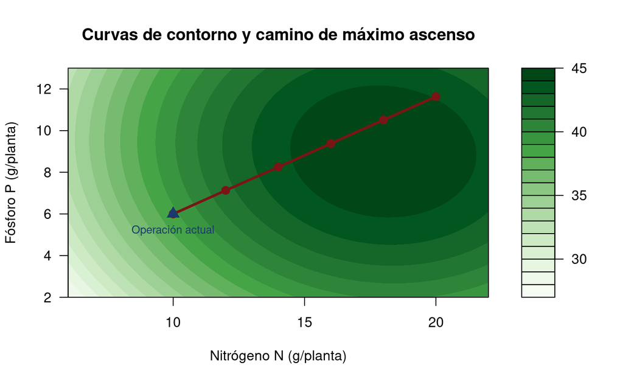

La superficie real (desconocida para el agrónomo) tiene su máximo cerca de $N=18$, $P=9$. El camino de máximo ascenso conduce naturalmente hacia esa vecindad.

## Errores comunes en el máximo ascenso

Advertencia: errores frecuentes

- Usar pasos demasiado grandes, lo que hace que el camino “salte” sobre la región óptima sin detectarla.
- Continuar el camino después de que la respuesta empieza a disminuir (señal clara de haber superado el óptimo).
- Aplicar el método de máximo ascenso cuando ya existe curvatura significativa: en ese caso se necesita directamente un modelo de segundo orden.
- Olvidar que la dirección de ascenso depende de la **escala de codificación**; cambiar los pasos del diseño cambia la dirección calculada.

Análisis de una superficie de segundo orden

Una vez en la vecindad del óptimo, el modelo lineal ya no es adecuado: se necesita capturar la curvatura de la superficie.

## El modelo de segundo orden

Cerca del óptimo, la superficie de respuesta presenta curvatura y se aproxima mejor mediante un polinomio de **segundo orden**:

Modelo de segundo orden (k = 2)

$$\hat y = b_0 + b_1 x_1 + b_2 x_2 + b_{11}x_1^2 + b_{22}x_2^2 + b_{12}x_1 x_2$$

- $b_{11}, b_{22}$: efectos cuadráticos puros (curvatura en cada eje).
- $b_{12}$: efecto de interacción (curvatura cruzada entre los dos factores).
- Este modelo ya no puede ajustarse con un diseño factorial $2^k$ simple: requiere un diseño que permita estimar términos cuadráticos (Parte III).

## Ubicación del punto estacionario: forma matricial

El modelo de segundo orden se escribe de forma compacta como $\hat y = b_0 + \mathbf{x}'\mathbf{b} + \mathbf{x}'\mathbf{B}\mathbf{x}$, con:

$$\mathbf{b}=\begin{pmatrix}b_1\\b_2\end{pmatrix}
\qquad
\mathbf{B}=\begin{pmatrix}b_{11} & b_{12}/2\\ b_{12}/2 & b_{22}\end{pmatrix}$$

Punto estacionario

Derivando $\hat y$ respecto a $\mathbf{x}$ e igualando a cero:
$$\mathbf{x}_s = -\frac{1}{2}\mathbf{B}^{-1}\mathbf{b}
\qquad
\hat y_s = b_0 + \frac{1}{2}\mathbf{x}_s'\,\mathbf{b}$$

$\mathbf{x}_s$ es el punto donde el gradiente de la superficie ajustada se anula: puede ser un máximo, un mínimo o un punto de silla.

## CCD para el ejemplo del tomate

| Corrida | $x_1$ | $x_2$ | N | P | y |
| --- | --- | --- | --- | --- | --- |
| 1 | -1 | -1 | 16.0 | 8.0 | 44.36 |
| 2 | +1 | -1 | 20.0 | 8.0 | 44.69 |
| 3 | -1 | +1 | 16.0 | 10.0 | 44.72 |
| 4 | +1 | +1 | 20.0 | 10.0 | 44.35 |
| 5 | $-\sqrt2$ | 0 | 15.17 | 9.0 | 44.25 |
| 6 | $+\sqrt2$ | 0 | 20.83 | 9.0 | 44.31 |
| 7 | 0 | $-\sqrt2$ | 18.0 | 7.59 | 44.90 |
| 8 | 0 | $+\sqrt2$ | 18.0 | 10.41 | 44.84 |
| 9-13 | 0 | 0 | 18.0 | 9.0 | 45.15, 45.09, 44.86, 45.20, 45.15 |

## Ajuste del modelo de segundo orden

Ajustando $\hat y = b_0 + b_1x_1 + b_2x_2 + b_{11}x_1^2 + b_{22}x_2^2 + b_{12}x_1x_2$ con las 13 corridas del CCD:

| Término | Estimación | Error estándar | valor-p |
| --- | --- | --- | --- |
| $b_0$ | 45.089 | 0.047 | $<0.001$ |
| $b_1$ ($x_1$) | 0.0061 | 0.037 | 0.874 |
| $b_2$ ($x_2$) | -0.0090 | 0.037 | 0.815 |
| $b_{11}$ ($x_1^2$) | -0.4149 | 0.040 | $<0.001$ |
| $b_{22}$ ($x_2^2$) | -0.1204 | 0.040 | 0.019 |
| $b_{12}$ ($x_1x_2$) | -0.1758 | 0.053 | 0.012 |

$R^2=0.946$. Los términos lineales ya no son significativos (el camino de ascenso “centró” bien el diseño), pero los términos cuadráticos y de interacción sí lo son: hay curvatura clara.

## Cálculo del punto estacionario

**Paso 1. Vector y matriz:**
$$\mathbf{b}=\begin{pmatrix}0.0061\\-0.0090\end{pmatrix}
\quad
\mathbf{B}=\begin{pmatrix}-0.4149 & -0.0879\\ -0.0879 & -0.1204\end{pmatrix}$$

**Paso 2. Punto estacionario codificado:**
$$\mathbf{x}_s = -\tfrac12 \mathbf{B}^{-1}\mathbf{b} = (0.018,\,-0.051)$$

**Paso 3. Conversión a unidades reales:**
$$N_s = 18 + 2(0.018) = 18.04 \text{ g/planta} \qquad P_s = 9 + 1(-0.051) = 8.95 \text{ g/planta}$$

Valor predicho en el punto estacionario: $\hat y_s = 45.089$ kg/planta.

## Superficie de respuesta ajustada

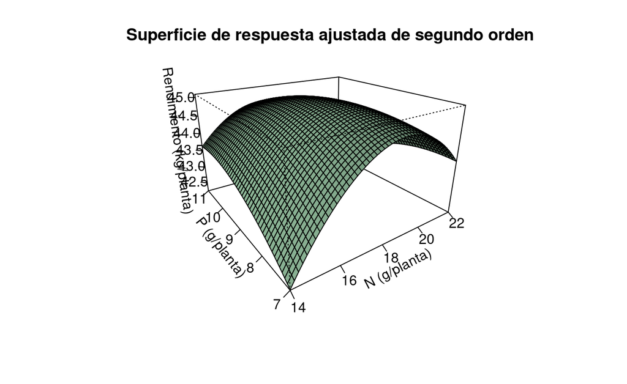

La superficie tiene forma de domo: existe un único máximo dentro de la región experimental, coincidente con el punto estacionario calculado.

## Caracterización: valores y vectores propios

Para determinar si el punto estacionario es un **máximo**, un **mínimo** o un **punto de silla**, se analizan los valores propios ($\lambda_1,\lambda_2$) de la matriz $\mathbf{B}$.

| Signo de los $\lambda_i$ | Naturaleza del punto estacionario |
| --- | --- |
| Todos negativos | Máximo |
| Todos positivos | Mínimo |
| Signos mixtos | Punto de silla |

Para el ejemplo del tomate: $\lambda_1=-0.096$, $\lambda_2=-0.439$. **Ambos valores propios son negativos**, por lo tanto el punto estacionario es un **máximo**.

El eje con $|\lambda|$ mayor ($\lambda_2=-0.439$) es la dirección de mayor curvatura: la superficie cae más rápido al alejarse del óptimo en ese eje.

## Interpretación agronómica del resultado

Conclusión del análisis

Las dosis óptimas estimadas son **N = 18.04 g/planta** y **P = 8.95 g/planta**, con un rendimiento máximo esperado de **45.09 kg/planta**, frente a los 38.7 kg/planta de la operación inicial: una mejora superior al 16%.

El agrónomo puede recomendar estas dosis con confianza, ya que el análisis confirma que corresponden a un máximo y no a un punto de silla.

## Sistemas de cresta (ridge systems)

En algunos procesos no existe un único óptimo bien definido, sino una **cresta**: una región alargada donde muchas combinaciones de factores producen una respuesta igualmente buena.

Cuándo aparece

Cuando uno de los valores propios de $\mathbf{B}$ es cercano a cero: la curvatura en esa dirección es casi nula.

Ejemplo agrícola

Riego y fertilización nitrogenada pueden sustituirse parcialmente: varias combinaciones (más riego/menos N, o menos riego/más N) producen rendimientos similares de caña de azúcar.

En un sistema de cresta, el agricultor tiene flexibilidad: puede elegir el punto de la cresta más económico, sin sacrificar rendimiento.

## Respuestas múltiples: motivación

En la práctica agrícola rara vez interesa optimizar una sola variable. El productor de tomate también podría querer maximizar la **calidad** del fruto (firmeza, contenido de sólidos solubles), no solo el rendimiento en kg/planta.

El problema: las dosis que maximizan el rendimiento ($N=18.0$, $P=8.95$) pueden no ser las mismas que maximizan la calidad del fruto.

## Función de deseabilidad

La **función de deseabilidad** de Derringer y Suich combina varias respuestas en un único índice $D \in [0,1]$, donde $D=1$ representa la situación ideal para todas las respuestas simultáneamente.

Idea general

Cada respuesta $y_i$ se transforma en una deseabilidad individual $d_i \in [0,1]$; la deseabilidad global es la media geométrica:
$$D = (d_1 \cdot d_2 \cdots d_m)^{1/m}$$

Ejemplo: para el tomate, $d_1$ mide qué tan cerca está el rendimiento de su máximo posible, y $d_2$ qué tan cerca está la firmeza del fruto de su valor ideal. Se buscan las dosis de N y P que maximizan $D$, en lugar de cada respuesta por separado.

Si $D=0$ para cualquier respuesta fuera de un rango aceptable, la deseabilidad global también es cero: ninguna respuesta puede “compensar” totalmente a otra que sea inaceptable.

Diseños experimentales para superficies de respuesta

¿Qué diseño experimental se necesita en cada etapa de la RSM?

## Diseños para el modelo de primer orden

Para estimar un modelo de primer orden se necesitan diseños eficientes que permitan calcular el gradiente con el menor número de corridas posible.

Factoriales $2^k$ (o fraccionados $2^{k-p}$)

Los más utilizados. Con $k=2$ o $3$ factores, se ejecutan en su forma completa más puntos centrales para estimar curvatura y error puro.

Diseños simplex

Usan $k+1$ puntos (un simplex geométrico) para $k$ factores: son la opción más económica cuando los recursos experimentales son muy limitados.

Ambos diseños son ortogonales o casi ortogonales, lo que facilita la estimación precisa de los coeficientes del modelo lineal.

## El diseño central compuesto (CCD)

El **diseño central compuesto** es el diseño más usado para ajustar modelos de segundo orden. Combina tres tipos de puntos:

**Puntos factoriales**  
$2^k$ corridas en los vértices ($\pm1$ en cada factor).

**Puntos axiales (estrella)**  
$2k$ corridas a distancia $\pm\alpha$ sobre cada eje, con los demás factores en su centro.

**Puntos centrales**  
$n_c$ réplicas en el centro del diseño, para estimar el error puro.

Para $k=2$ factores y $\alpha=\sqrt2$ (CCD rotable), el diseño usado en el ejemplo del tomate tuvo $4+4+5=13$ corridas en total.

## Estructura geométrica del CCD ($k=2$)

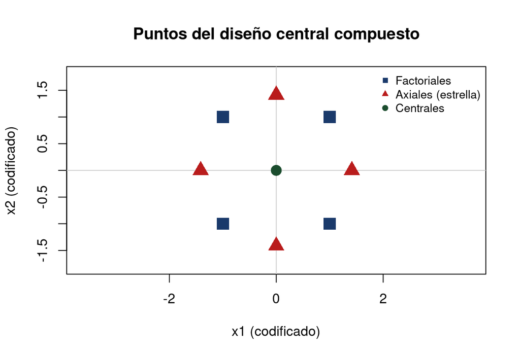

## Elección de $\alpha$ y número de puntos centrales

El valor de $\alpha$ y el número de puntos centrales $n_c$ se eligen para que el CCD tenga propiedades deseables, como la rotabilidad (la varianza de predicción depende solo de la distancia al centro).

| k (factores) | $\alpha$ rotable ($2^{k/4}$) | $n_c$ recomendado |
| --- | --- | --- |
| 2 | 1.414 | 5 |
| 3 | 1.682 | 6 |
| 4 | 2.000 | 7 |

En el ejemplo del tomate ($k=2$), se usó $\alpha=1.414$ y $n_c=5$, siguiendo la recomendación estándar para diseños rotables.

## Bloqueo en diseños de superficie de respuesta

Cuando el experimento no puede ejecutarse en condiciones homogéneas (varios días de siembra, distintos lotes de fertilizante, varios invernaderos), se introduce el **bloqueo** para aislar esa fuente de variación.

Un CCD se puede dividir en dos bloques: uno con los puntos factoriales + algunos centrales, y otro con los puntos axiales + el resto de los centrales.

## Diseños óptimos generados por computador

Cuando la región experimental tiene restricciones (por ejemplo, no se puede aplicar simultáneamente dosis muy altas de N y muy bajas de riego), los diseños clásicos (factorial, CCD) pueden no ser aplicables directamente.

Criterio D-óptimo

Selecciona los puntos experimentales que minimizan el volumen de la región de confianza de los coeficientes (maximiza $|\mathbf{X}'\mathbf{X}|$).

Cuándo usarlos

Regiones experimentales irregulares, número de corridas fijo por presupuesto, o combinación de factores cualitativos y cuantitativos.

Estos diseños se generan con algoritmos computacionales (intercambio de puntos) y no tienen, en general, una estructura geométrica tan simple como el CCD.

Otros enfoques de optimización de procesos

La RSM clásica no es la única herramienta disponible para optimizar procesos agrícolas.

## Experimentos con mezclas

En los **experimentos con mezclas**, los factores son las proporciones de los componentes de una mezcla, y deben sumar siempre el 100%. Esto los distingue de los factoriales clásicos, donde cada factor varía de forma independiente.

Restricción de mezcla

$$x_1 + x_2 + \cdots + x_q = 1, \qquad x_i \geq 0$$

Ejemplo agrícola: un vivero de flores en Madrid (Cundinamarca) busca la mezcla óptima de sustrato para semilleros, combinando turba, cascarilla de arroz y compost, en proporciones que suman 100%, para maximizar el porcentaje de germinación.

La región experimental ya no es un cubo o una esfera, sino un símplex (triángulo para $q=3$ componentes), lo que exige diseños específicos (simplex-lattice, simplex-centroide).

## Operación evolutiva (EVOP)

La **Operación Evolutiva** (EVOP) permite optimizar un proceso que ya está en producción, mediante pequeños cambios secuenciales, **sin detener la operación** y sin asumir los riesgos de un cambio drástico.

Idea central

Se ejecutan ciclos pequeños de variaciones en torno a las condiciones actuales de operación (un “factorial pequeño” repetido en el tiempo), acumulando información hasta detectar mejoras significativas.

Ejemplo agrícola

Una planta de beneficio de café en producción continua ajusta gradualmente la dosis de cal usada en el lavado del grano, probando pequeñas variaciones cada semana sin detener el proceso productivo.

EVOP es más lento que un experimento diseñado clásico, pero evita interrumpir la producción mientras se busca la mejora.

## Diseño robusto de procesos: antecedentes

El enfoque de **diseño robusto**, propuesto originalmente por Genichi Taguchi, distingue dos tipos de factores que afectan un proceso.

Factores de control

Variables que el productor puede fijar y manipular: dosis de fertilizante, densidad de siembra, variedad de semilla.

Factores de ruido

Variables que afectan la respuesta pero que **no** se pueden controlar en campo: temperatura, precipitación, radiación solar.

El objetivo del diseño robusto no es solo maximizar la media de la respuesta, sino encontrar condiciones que sean buenas **en promedio** y, además, poco sensibles a la variabilidad de los factores de ruido.

## Enfoque de superficie de respuesta para diseño robusto

La extensión moderna del diseño robusto usa RSM para modelar simultáneamente la **media** y la **varianza** de la respuesta en función de los factores de control y de ruido.

Modelos de media y varianza

$$\hat\mu_y(\mathbf{x}) \qquad \text{y} \qquad \hat\sigma^2_y(\mathbf{x})$$
se ajustan como funciones de los factores de control $\mathbf{x}$, combinando luego ambos objetivos (ej. maximizar $\hat\mu_y$ sujeto a una cota en $\hat\sigma^2_y$).

Ejemplo agrícola: un caficultor en el Huila busca la combinación de variedad y densidad de siembra que produzca un rendimiento alto en promedio, pero que también sea estable frente a años de sequía o exceso de lluvia.

Una práctica más rentable en promedio, pero muy sensible al clima, puede ser menos deseable que una práctica algo menos rentable pero mucho más estable.

## Resumen general de la clase

La RSM avanza secuencialmente: primero un modelo de primer orden y máximo ascenso para acercarse al óptimo, luego un modelo de segundo orden (vía CCD) para caracterizarlo mediante el punto estacionario y el análisis de valores propios. Cuando hay varias respuestas, se recurre a la deseabilidad; cuando no hay óptimo único, aparecen sistemas de cresta. Las mezclas, EVOP y el diseño robusto son extensiones del mismo espíritu de optimización experimental.

En el ejemplo central, las dosis óptimas de N=18.04 g/planta y P=8.95 g/planta llevaron el rendimiento de 38.7 a 45.09 kg/planta de tomate.

## Taller en Clase

## Instrucciones

Resuelva los siguientes ejercicios aplicando los conceptos de la Metodología de Superficie de Respuesta vistos en esta clase. Para cada ejercicio:

1. Identifique las variables (factores y respuesta) y su tipo de diseño.
2. Realice los cálculos solicitados paso a paso (dirección de ascenso, punto estacionario, valores propios, según corresponda).
3. Interprete el resultado en el contexto agrícola del problema.
4. Discuta posibles errores comunes que deben evitarse al aplicar el método.

Trabaje en grupos de máximo 3 estudiantes. Tiempo estimado: 35 minutos.

## Ejercicio 1

Un cultivador de papa en Nariño ajusta un modelo de primer orden para el rendimiento (ton/ha) en función de la dosis de potasio ($x_1$) y la frecuencia de riego ($x_2$), codificadas en $[-1,1]$:
$$\hat y = 24.6 + 1.8x_1 + 3.2x_2$$

1. Calcule la razón $b_2/b_1$ y la dirección de máximo ascenso.
2. Si el paso de referencia es $\Delta x_1=1$, calcule $\Delta x_2$.
3. Si el centro del diseño es $x_1=20$ kg/ha de potasio (paso 5) y $x_2=2$ riegos/semana (paso 1), construya la tabla de los primeros 3 puntos del camino de ascenso en unidades reales.

## Ejercicio 2

En una plantación de caña de azúcar en el Valle del Cauca se ajustó un modelo de segundo orden para el contenido de sacarosa (%) en función de la dosis de nitrógeno ($x_1$) y de potasio ($x_2$):
$$\hat y = 14.2 + 0.15x_1 + 0.08x_2 - 0.25x_1^2 - 0.10x_2^2 + 0.05x_1x_2$$

1. Escriba el vector $\mathbf{b}$ y la matriz $\mathbf{B}$ del modelo.
2. Calcule el punto estacionario codificado $\mathbf{x}_s$.
3. Calcule los valores propios de $\mathbf{B}$ y determine si el punto estacionario es un máximo, un mínimo o un punto de silla.

## Ejercicio 3

Un agrónomo de flores en Madrid (Cundinamarca) desea diseñar un CCD para 2 factores: temperatura del invernadero ($x_1$) y humedad relativa ($x_2$), con el fin de maximizar el número de tallos comerciales de rosa por planta.

1. Liste los puntos del CCD (factoriales, axiales y centrales) usando $\alpha=1.414$ y $n_c=5$, en variables codificadas.
2. Si el centro real es $T=22°C$ (paso $2°C$) y $HR=70\%$ (paso $5\%$), convierta los 13 puntos del diseño a unidades reales.
3. Explique por qué este diseño no podría usarse para estimar únicamente un modelo de primer orden de forma eficiente.

## Ejercicio 4

Una empresa de flores busca simultáneamente maximizar la longitud del tallo (respuesta 1) y minimizar el porcentaje de pétalos dañados por hongos (respuesta 2), ambas en función de la dosis de fungicida y la frecuencia de ventilación del invernadero.

1. Explique por qué este es un problema de respuestas múltiples y no se puede resolver optimizando cada respuesta por separado.
2. Proponga, en palabras, cómo construiría las deseabilidades individuales $d_1$ y $d_2$ para cada respuesta.
3. Discuta qué ocurriría con la deseabilidad global $D$ si una combinación de factores produce el tallo más largo posible pero también el mayor daño por hongos.

## Ejercicio 5

Una planta procesadora de panela en Santander, ya en operación continua, desea mejorar el rendimiento de panela por tonelada de caña sin detener la producción diaria.

1. Justifique por qué la Operación Evolutiva (EVOP) es más adecuada aquí que un CCD clásico.
2. Proponga dos factores de control y dos posibles factores de ruido relevantes para este proceso.
3. Describa, en términos generales, cómo se vería un ciclo de EVOP para esta planta (qué cambios pequeños probaría y cómo decidiría si conservarlos).